# Global Temps

Evan Uribe

July 4, 2019

```r
# remove global environment
rm(list = ls())

showCode = TRUE
fileName = 'data/GlobalTemperatures.csv'
skipcols =c ('LandAverageTemperatureUncertainty','LandMaxTemperatureUncertainty',
           'LandMinTemperatureUncertainty','LandAndOceanAverageTemperatureUncertainty',
           'LandMinTemperature')
```

Read the data and filter out ‘uncertainty’ columns and filter dates from 1850 to 2015

```r
globaltemps <- read.csv(fileName)
globaltemps [ , skipcols] <- list(NULL)  # delete these columns
globaltemps$dt = as.Date(globaltemps$dt) # convert dt to Date object

# filter by dates
library(dplyr)
globaltemps <- globaltemps %>%
  filter(dt >= as.Date("1850-01-01") & dt <= as.Date("2015-12-01"))

dim (globaltemps) # show its dimensions
```

```
[1] 1992    4
```

Function Definitions

```r
# supporess library load warning messages
shhh <- suppressPackageStartupMessages

shhh (library (grid))
shhh (library(tidyr))
shhh (library(ggplot2))
shhh (library(tidyverse) )     # data manipulation and visualization
shhh (library(lubridate) )     # easily work with dates and times
shhh (library(fpp2))          # working with time series data
shhh (library(zoo))           # working with time series data



##### helper function to plot mulitple plots on the same panel (i.e. similiar to subplots)
multiplot <- function(..., plotlist=NULL, cols) {

    # Make a list from the ... arguments and plotlist
    plots <- c(list(...), plotlist)

    numPlots = length(plots)

    # Make the panel
    plotCols = cols                          # Number of columns of plots
    plotRows = ceiling(numPlots/plotCols) # Number of rows needed, calculated from # of cols

    # Set up the page
    grid.newpage()
    pushViewport(viewport(layout = grid.layout(plotRows, plotCols)))
    vplayout <- function(x, y)
        viewport(layout.pos.row = x, layout.pos.col = y)

    # Make each plot, in the correct location
    for (i in 1:numPlots) {
        curRow = ceiling(i/plotCols)
        curCol = (i-1) %% plotCols + 1
        print(plots[[i]], vp = vplayout(curRow, curCol ))
    }
}

#### Plot time series for each variable
plotIndividualPlots <- function(startDt="1850-01-01", endDt="2015-12-01") {

  ss <- subset(globaltemps, dt >= as.Date(startDt) & dt <= as.Date(endDt))

  p1 <- ggplot(data = ss, aes(x = dt, y = LandAverageTemperature))+
    geom_line(color = "green", size = 1) +
    ggtitle(paste('LandAverageTemperature', startDt, '-', endDt)) +
    xlab('date') + ylab('temperature')

  p2 <- ggplot(data = ss, aes(x = dt, y = LandMaxTemperature))+
      geom_line(color = "orange", size = 1)+
      ggtitle(paste('LandMaxTemperature', startDt, '-', endDt)) +
      xlab('date') + ylab('temperature')

  p3 <- ggplot(data = ss, aes(x = dt, y = LandAndOceanAverageTemperature))+
      geom_line(color = "blue", size = 1)+
      ggtitle(paste('LandAndOceanAverageTemperature', startDt, '-', endDt)) +
      xlab('date') + ylab('temperature')

  multiplot(p1, p2, p3, cols=2)
}

#### time series plot
plotTimeSeries <- function(startDt="1850-01-01", endDt="2015-12-01", colName=NULL) {

 ss <- subset(globaltemps, dt >= as.Date(startDt) & dt <= as.Date(endDt))

 df <- ss %>%
    select(dt, LandAverageTemperature, LandMaxTemperature,LandAndOceanAverageTemperature) %>%
    gather(key = "variable", value = "value", -dt)

  p <- ggplot(df, aes(x = dt, y = value)) +
    geom_line(aes(color = variable), size = 1) +
    scale_color_manual(values = c("blue", "green", "orange")) +
    ggtitle(paste('Temperatures', startDt, '-', endDt)) +
    xlab('date') + ylab('temperature')

  p + theme(plot.title = element_text(color="black", size=10, face="bold", hjust=0.5),
       axis.title.x = element_text(color="black", size=8),
       axis.title.y = element_text(color="black", size=8)) +
       #theme(legend.position = "none") # hides the legend +
       theme(legend.position="bottom")
}



####  functions to plot moving average

plotMovingAvgAll <- function(startDt="1850-01-01", endDt="2015-12-01", kval=121) {

  ss <- subset(globaltemps, dt >= as.Date(startDt) & dt <= as.Date(endDt))

  temp.zoo <- zoo(ss$LandAverageTemperature, ss$dt)
  temp2.zoo <- zoo(ss$LandMaxTemperature, ss$dt)
  temp3.zoo <- zoo(ss$LandAndOceanAverageTemperature, ss$dt)

  # rolling averaage
  m.av <- rollmean(temp.zoo, k=kval, fill=NA)
  ss$LandAverageTemperature.ma = coredata(m.av)

  #m2.av<-rollmean(temp2.zoo,121,fill=list(NA,NULL,NA))
  m2.av <- rollmean(temp2.zoo, k=kval, fill=NA)
  ss$LandMaxTemperature.ma = coredata(m2.av)

  m3.av <- rollmean(temp3.zoo, k=kval, fill=NA)
  ss$LandAndOceanAverageTemperature.ma = coredata(m3.av)

  # now remove thse columns prior to plotting
  ss <- subset(ss, select = -c(LandAverageTemperature, LandMaxTemperature,
                               LandAndOceanAverageTemperature))

  # now plot
  shhh (library(reshape))

  ss.long <- melt(ss, id.vars="dt")
  p = ggplot(data = ss.long, aes(dt, value, color=variable), na.rm=TRUE) +
    geom_line(na.rm=TRUE)+
    xlab('date') + ylab('temperature')

  p + theme(plot.title = element_text(color="black", size=10, face="bold", hjust=0.5),
       axis.title.x = element_text(color="black", size=8),
       axis.title.y = element_text(color="black", size=8)) +
       theme(legend.position="bottom")

}

# plot a single moving average with only moving average data
plotMovingAvg <- function(startDt="1850-01-01", endDt="2015-12-01", colName=NULL, kval=121) {

   ss <- subset(globaltemps, dt >= as.Date(startDt) & dt <= as.Date(endDt))

   tempdf <- ss %>%
      select(dt, temps = colName) %>%
      mutate(ma10 = rollmean(temps, k = kval, fill = NA))

  # now plot
  tempdf %>%
    gather(metric, value, ma10) %>%
    ggplot(aes(dt, value, color = metric), na.rm=TRUE) +
    geom_line(na.rm=TRUE) +
    ggtitle(paste(colName[1], startDt,  "-", endDt)) +
    xlab("date") + ylab("temperature")
}

# plot a single moving average and includes the original data
plotMovingAvg2 <- function(startDt="1850-01-01", endDt="2015-12-01", colName=NULL, kval=121) {

    s = as.Date(startDt)
    year <- as.numeric(format(s,'%Y'))

    ss <- subset(globaltemps, dt >= s & dt <= as.Date(endDt))

    temps.ts <- ss %>%
       select(temp = colName) %>%
          ts(start = c(year, 1), frequency = 12)  # convert to time series

    head(temps.ts, 12)

    # now plot
   p = autoplot(temps.ts, series = "LandAverageTemperature") +
      autolayer(ma(temps.ts, kval), series = "10 yr MA", na.rm=TRUE) +
      ggtitle(paste('Temperatures:', startDt,  "-", endDt)) +
      xlab("date") + ylab("temperature")

    p + theme(plot.title = element_text(color="black", size=10, face="bold", hjust=0.5),
         axis.title.x = element_text(color="black", size=8),
         axis.title.y = element_text(color="black", size=8)) +
         theme(legend.position="bottom")

}

###
firstOrderDiffPlot <- function(startDt="1850-01-01", endDt="2015-12-01", colName=NULL) {
  s = as.Date(startDt)
  year <- as.numeric(format(s,'%Y'))

  ss <- subset(globaltemps, dt >= s & dt <= as.Date(endDt))
  ts1 <- ss %>%
       select(temp = colName) %>%
          ts(start = c(year, 1), frequency = 12)  # convert to time series

    plot(diff(ts1), xlab = "date",  ylab="temperature", main=colName[1])
    #plot(diff(log(ts1)))

    return(diff(ts1))
}
```

Verify the starting date range

```r
head(globaltemps, 3)
```

|  | dt | LandAverageTemperature | LandMaxTemperature | LandAndOceanAverageTemperature |
| --- | --- | --- | --- | --- |
| 1 | 1850-01-01 | 0.749 | 8.242 | 12.833 |
| 2 | 1850-02-01 | 3.071 | 9.970 | 13.588 |
| 3 | 1850-03-01 | 4.954 | 10.347 | 14.043 |

Verify the ending date range

```r
tail (globaltemps, 3)
```

|  | dt | LandAverageTemperature | LandMaxTemperature | LandAndOceanAverageTemperature |
| --- | --- | --- | --- | --- |
| 1990 | 2015-10-01 | 10.801 | 16.450 | 16.290 |
| 1991 | 2015-11-01 | 7.433 | 12.892 | 15.252 |
| 1992 | 2015-12-01 | 5.518 | 10.725 | 14.774 |

#### Plot ‘LandAverageTemperature’, ‘LandAndOceanAverageTemperature’,’LandMaxTemperature

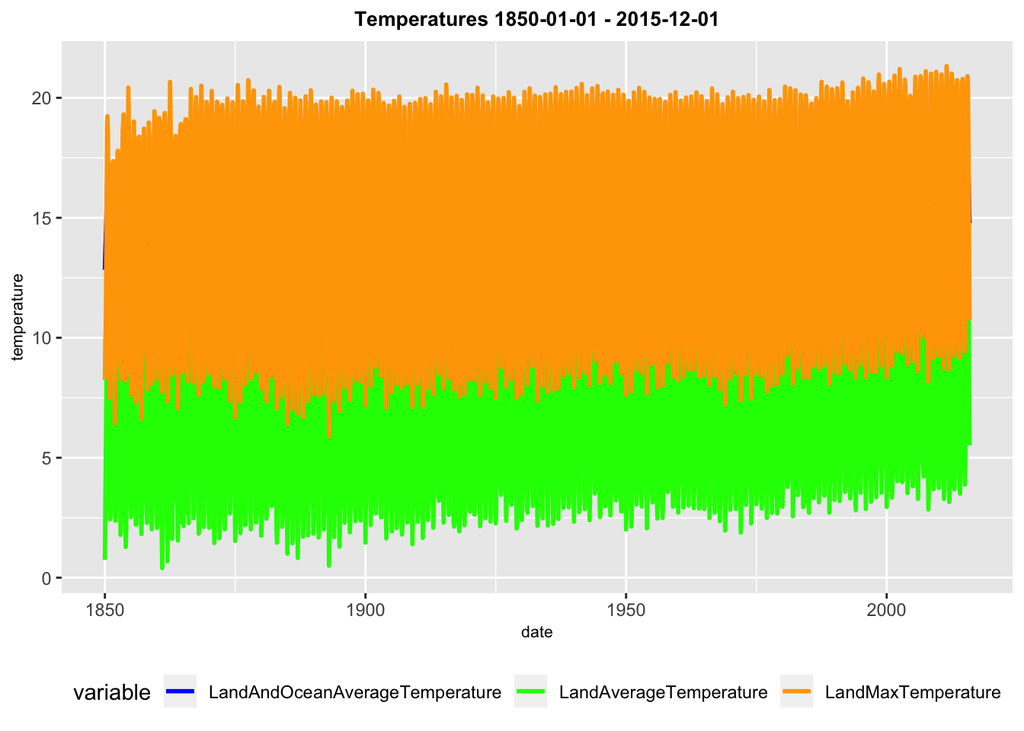

```r
plotTimeSeries()
```

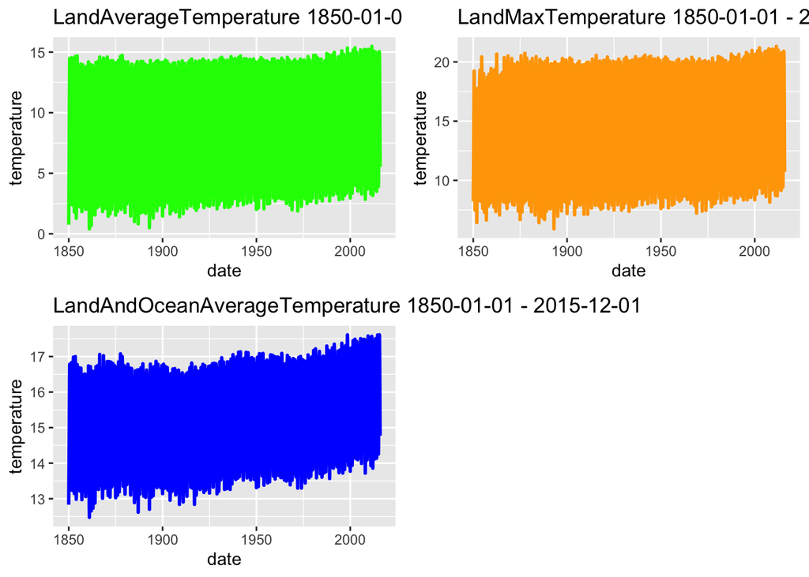

```r
plotIndividualPlots()
```

The plots show periocidicy as well as a gradual upward trend. From the invidual graphs, increased warming looks to have become more constant starting around the 1970’s with sharper increases evident in 1990’s and continuting to the current period.

But given the wide range of years (165), it’s difficult to make out the specifics, so let’s plot for a shorter period.

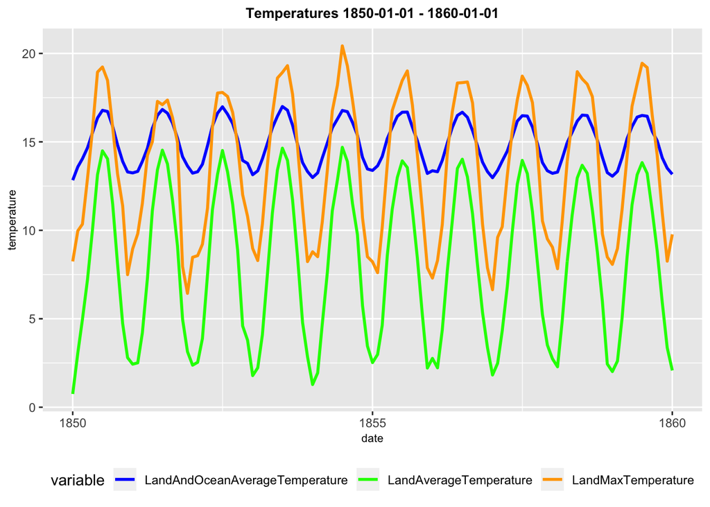

```r
# first 10 years
plotTimeSeries(endDt = '1860-01-01')
```

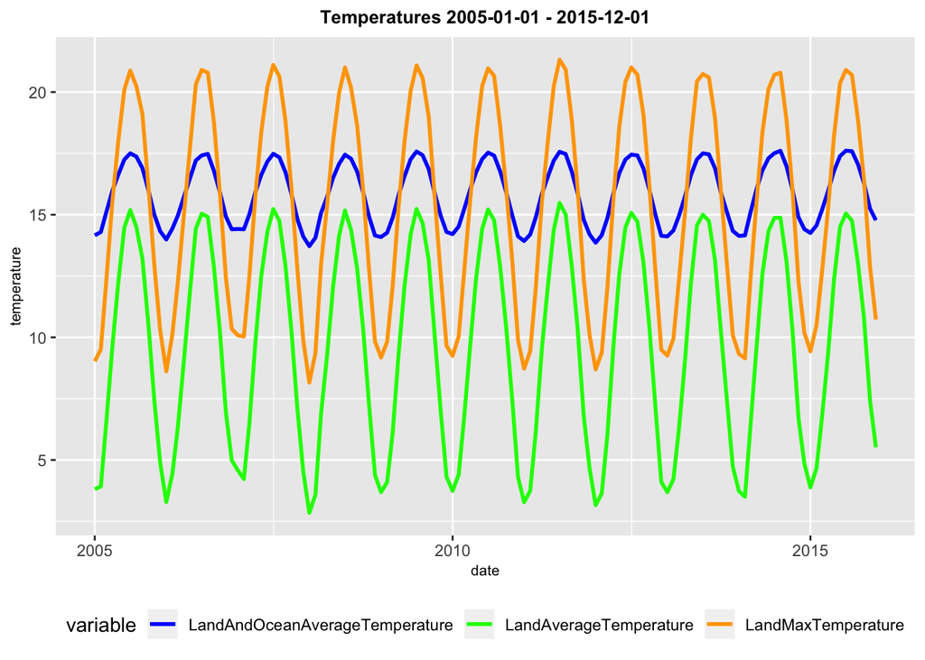

```r
# last 10 years
plotTimeSeries(startDt = '2005-01-01')
```

##### Identifying Trends in Time Series

Time series data often exhibit some slow, gradual variability in addition to higher frequency variability such as seasonality and noise. An easy way to visualize these trends is with rolling means at different time scales. While we have observed seasonal trends in the graphs above, by taking rolling averages we will be able to better visualize the upward trend.

With a rolling average for each time point, the average of the points on either side of it is taken. The affect is that it smooths out noise and seasonality, allowing visualization of trends.

Let’s take 10 year rolling averages for each variable.

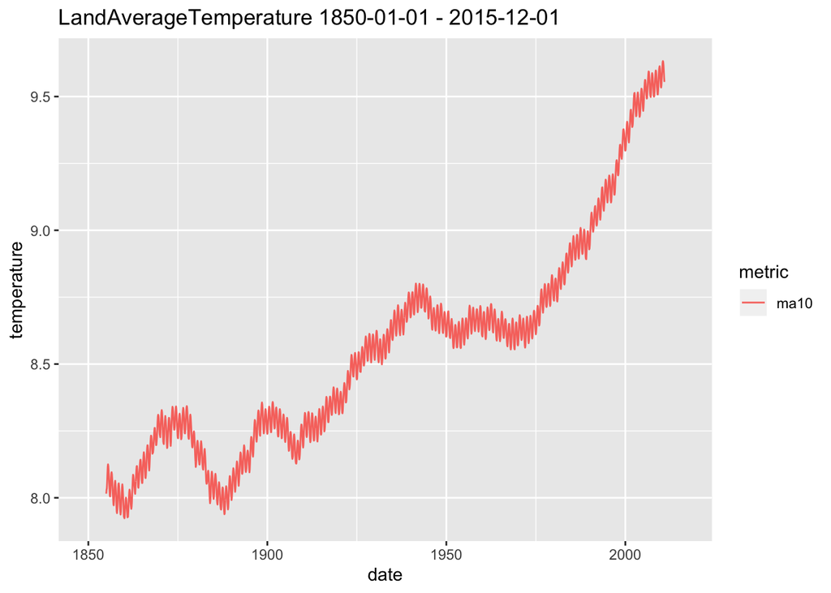

```r
plotMovingAvg(colName=c('LandAverageTemperature'))
```

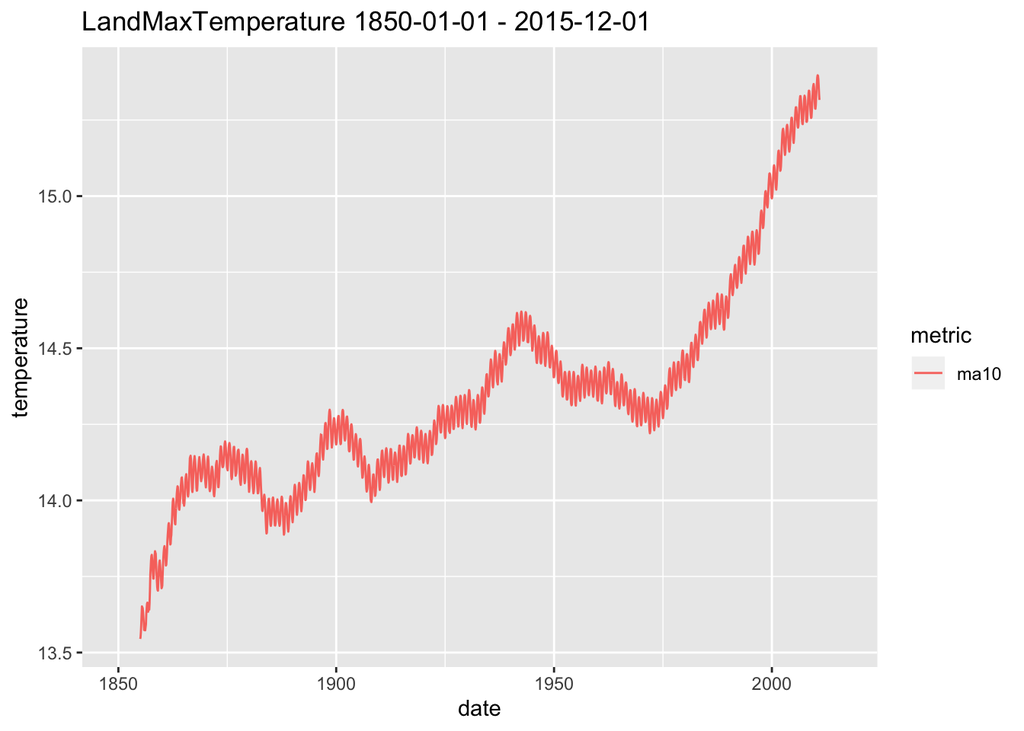

```r
plotMovingAvg(colName=c('LandMaxTemperature'))
```

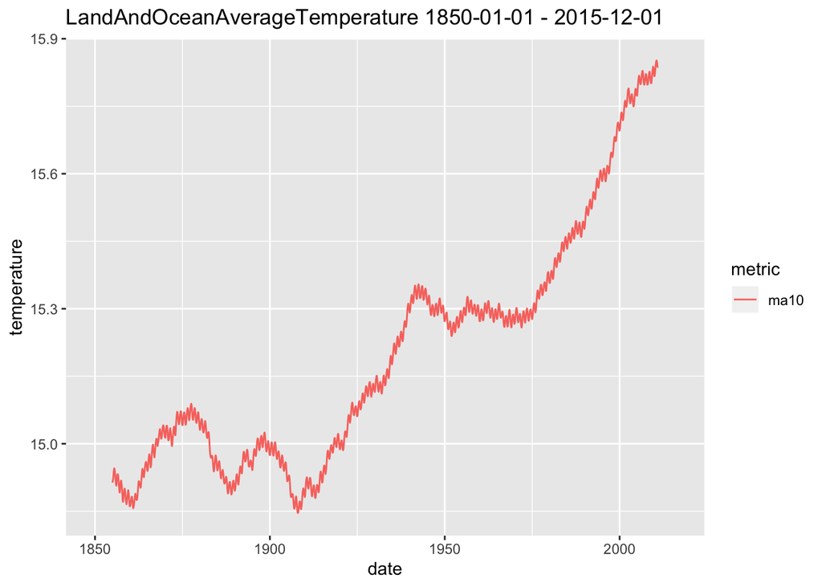

```r
plotMovingAvg(colName=c('LandAndOceanAverageTemperature'))
```

All 3 variables show clear upward trends. The steady climb in temperature is most evident in the period from 1900 to 1944, then a stabilization from 1944 to 1970 and then again a steady climb from 1970 to the current day. The over-all trend is upwards.

Let’s view each of these together in a single graph for comparision.

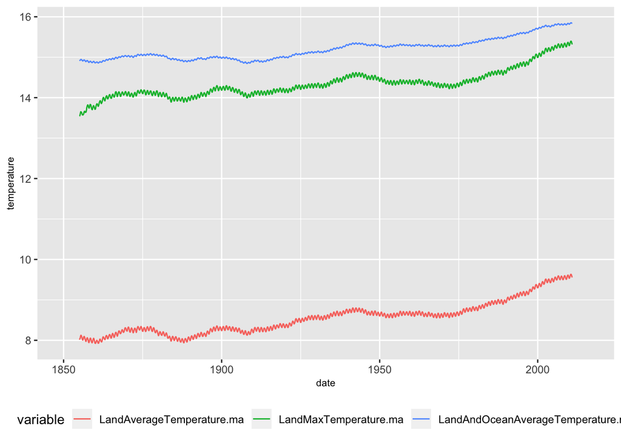

```r
plotMovingAvgAll()
```

Here, we see an over-all upward trend. All 3 variables mirror eachother with matching peaks and valleys.

While much of the seasonality was removed using rolling averages, to further explore seasonality, we can remove the trend from the time series.

#### Seasonal Patterns in Time Series Data

One way to remove the trend is called “differencing”, where we look at the difference between successive data points (“first-order differencing”), because we’re only looking at the difference between one data point and the one before it).

Differencing is helpful in turning time series into a stationary time series. Stationary time series is one whose statistical properties (such as mean and variance) don’t change over time. These time series are useful because many time series forecasting methods are based on the assumption that the time series is approximately stationary.

Start off by plotting the first-order difference.

```r
 level_of_difference <- ndiffs(LandAverageTemperature)
 diff_data <- diff(LandAverageTemperature, level_of_difference)
 diff_data = ts(diff_data, start = c(1850, 1), frequency = 12)  # convert to time series

 plot(diff_data, xlab = 'date', ylab="temperature",
      main="first order difference LandAverageTemperature")
 # tsdisplay(LandAverageTemperature)
```

[output not shown]

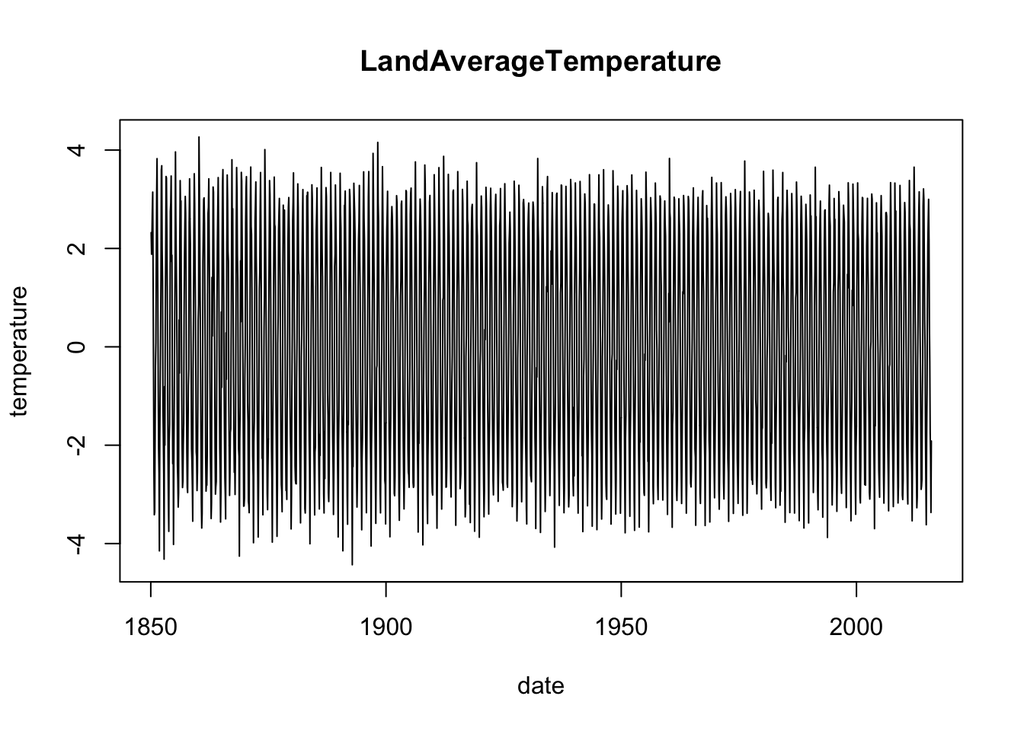

```r
ts1 = firstOrderDiffPlot (colName=c('LandAverageTemperature'))
```

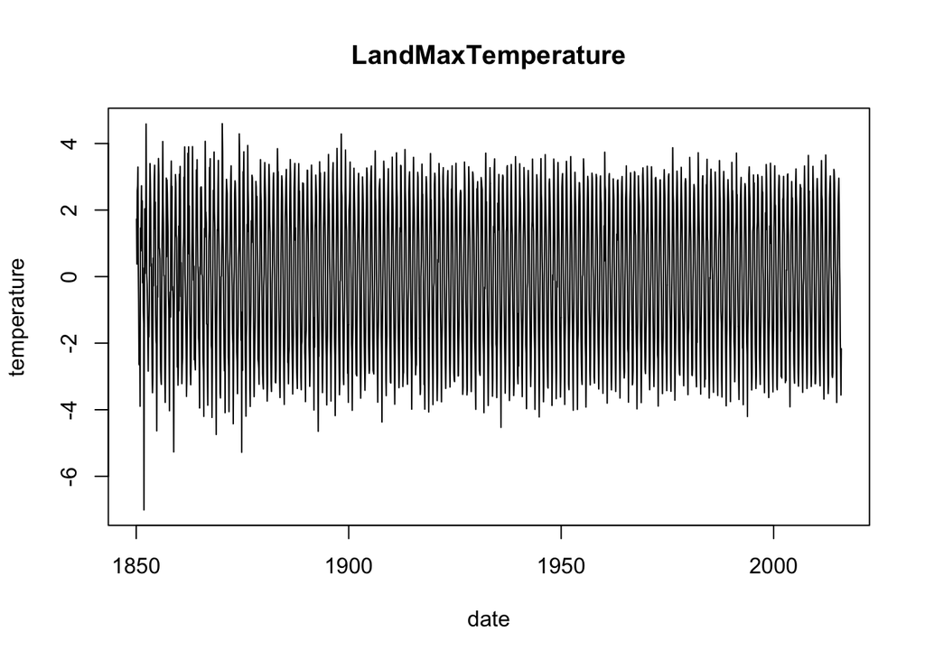

```r
ts2= firstOrderDiffPlot (colName=c('LandMaxTemperature'))
```

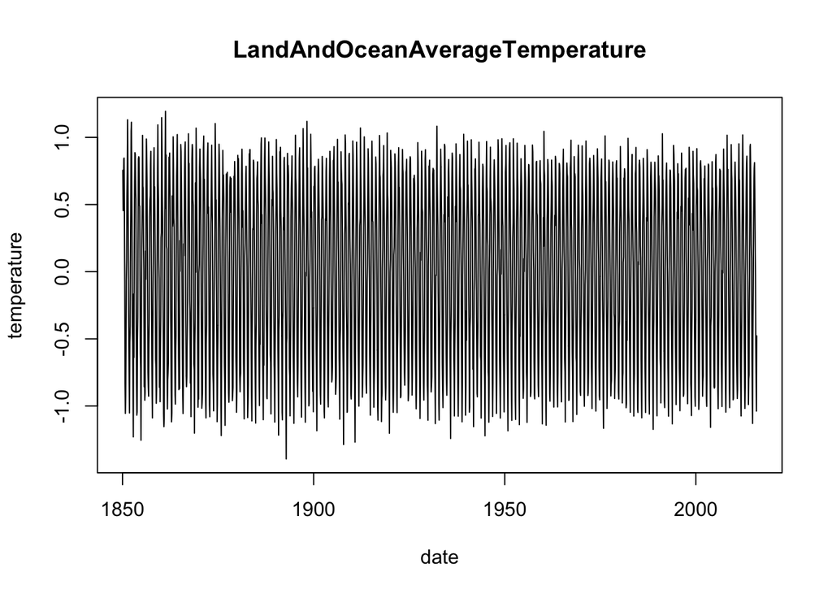

```r
ts3=firstOrderDiffPlot (colName=c('LandAndOceanAverageTemperature'))
```

From the graph, we do see seasonal patterns. 1852 stands out as having been unusually cold, given a large negative spike in LandMaxTemperature.

```r
firstOrderDiff <- data.frame(ts1, ts2, ts3)
names(firstOrderDiff) <- c("LandAverageTemperature", "LandMaxTemperature", "LandAndOceanAverageTemperature")
```

#### Periodicity and Autocorrelation

A time series is periodic if it repeats itself at equally spaced intervals, say, every 12 months. The time series is correlated with itself shifted by 12 months. That means that, if you took the time series and moved it 12 months backwards or forwards, it would map onto itself in some way.

```r
df = subset(globaltemps, select = -c(dt))
cor(df)
```

```
                               LandAverageTemperature LandMaxTemperature
LandAverageTemperature                      1.0000000          0.9958072
LandMaxTemperature                          0.9958072          1.0000000
LandAndOceanAverageTemperature              0.9880656          0.9838551
                               LandAndOceanAverageTemperature
LandAverageTemperature                              0.9880656
LandMaxTemperature                                  0.9838551
LandAndOceanAverageTemperature                      1.0000000
```

Everything is highly correleated, which is not unexpected given that all variables are some view into land temperature.

The actual correlation coefficient is actually capturing both season and trend. By plotting the first-order differences of these time series and then computing the correlation we get the correlation of the seasonal components, approximately.

```r
  cor(firstOrderDiff)
```

```
                               LandAverageTemperature LandMaxTemperature
LandAverageTemperature                      1.0000000          0.9844758
LandMaxTemperature                          0.9844758          1.0000000
LandAndOceanAverageTemperature              0.9899514          0.9776104
                               LandAndOceanAverageTemperature
LandAverageTemperature                              0.9899514
LandMaxTemperature                                  0.9776104
LandAndOceanAverageTemperature                      1.0000000
```

#### Autocorrelation Plots

Here, we look at the plots and what we expect to see is a spike in autocorrelation at 12 months: the time series is correlated with itself shifted by twelve months. This makes sensense given the yearly seasonal patterns of weather and its correlation to land temperature.

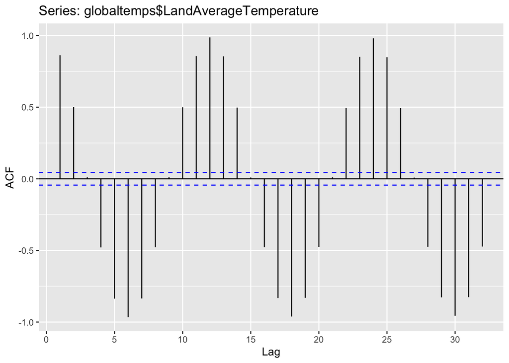

```r
ggAcf(globaltemps$LandAverageTemperature)
```

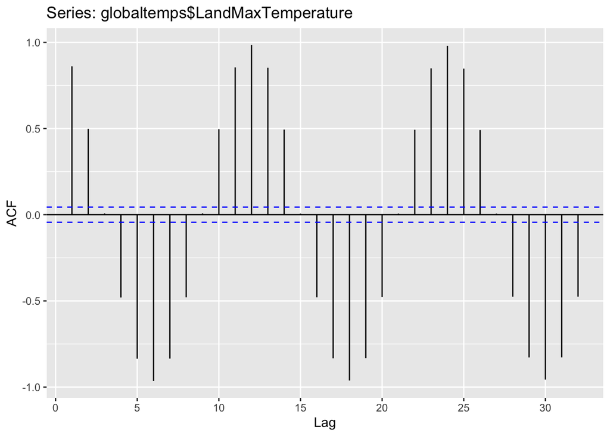

```r
ggAcf(globaltemps$LandMaxTemperature)
```

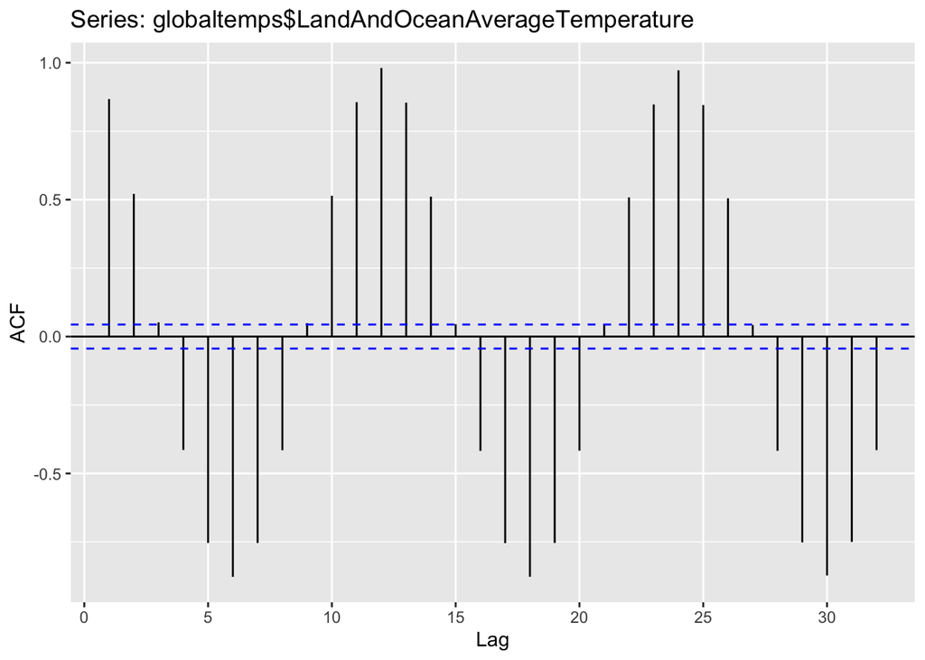

```r
ggAcf(globaltemps$LandAndOceanAverageTemperature)
```